# IODS final project

Petri Heinonen

# # Logistic Regression Churn Modeling

In this last assignment, I’ll build a simple churn model with logistic regression. I’ll build the model with three variables:

1. The number of customer service calls
2. The length of account in days
3. The total charge

My hypoteses is that a larger number of customer service calls and total charge increase customer unsatisfaction and lead to churn. The longer length of account shows customer loyalty and probably decreases churn.

The dataset “churn” is from UCI: http://www.sgi.com/tech/mlc/db/ I haven’t done separate data wrangling file, because data transform in this case is fairly straight-forward.

Dataset includes customer data with 5000 observations and 22 variables. Probably it’s from telco industry where churn management is widely used. I chose three variables that I would think to predict customer churn.

I’ll use logistic regression because target variable is binary. Customer either churns or stays.

First, I’ll read the variable names

```r
# Load libraries
library(ggplot2)

# load both the variable names file and the variable values file
varNms = read.csv("http://www.sgi.com/tech/mlc/db/churn.names", skip=4, header=FALSE,
               sep=":", colClasses=c("character", "NULL"))[[1]]

print(varNms)
```

```
##  [1] "state"                         "account length"
##  [3] "area code"                     "phone number"
##  [5] "international plan"            "voice mail plan"
##  [7] "number vmail messages"         "total day minutes"
##  [9] "total day calls"               "total day charge"
## [11] "total eve minutes"             "total eve calls"
## [13] "total eve charge"              "total night minutes"
## [15] "total night calls"             "total night charge"
## [17] "total intl minutes"            "total intl calls"
## [19] "total intl charge"             "number customer service calls"
```

Next, I’ll add variable values

```r
dt = read.csv("http://www.sgi.com/tech/mlc/db/churn.all", header=FALSE, col.names=c(varNms,"churn"))
print(head(dt))
```

```
##   state account.length area.code phone.number international.plan
## 1    KS            128       415     382-4657                 no
## 2    OH            107       415     371-7191                 no
## 3    NJ            137       415     358-1921                 no
## 4    OH             84       408     375-9999                yes
## 5    OK             75       415     330-6626                yes
## 6    AL            118       510     391-8027                yes
##   voice.mail.plan number.vmail.messages total.day.minutes total.day.calls
## 1             yes                    25             265.1             110
## 2             yes                    26             161.6             123
## 3              no                     0             243.4             114
## 4              no                     0             299.4              71
## 5              no                     0             166.7             113
## 6              no                     0             223.4              98
##   total.day.charge total.eve.minutes total.eve.calls total.eve.charge
```

[output cut: 27 more lines]

```r
# recode churn variable into zeros and ones
as.integer(as.logical(dt$churn))
```

[output not shown]

[output cut: 203 more lines]

```r
# create total charge columns
dt$total.charge = dt$total.day.charge + dt$total.eve.charge + dt$total.night.charge + dt$total.intl.charge


# inspect data frame
str(dt)
```

```
## 'data.frame':    5000 obs. of  22 variables:
##  $ state                        : Factor w/ 51 levels "AK","AL","AR",..: 17 36 32 36 37 2 20 25 19 50 ...
##  $ account.length               : int  128 107 137 84 75 118 121 147 117 141 ...
##  $ area.code                    : int  415 415 415 408 415 510 510 415 408 415 ...
##  $ phone.number                 : Factor w/ 5000 levels " 327-1058"," 327-1319",..: 2846 2302 1617 2511 156 3356 1517 117 426 164 ...
##  $ international.plan           : Factor w/ 2 levels " no"," yes": 1 1 1 2 2 2 1 2 1 2 ...
##  $ voice.mail.plan              : Factor w/ 2 levels " no"," yes": 2 2 1 1 1 1 2 1 1 2 ...
##  $ number.vmail.messages        : int  25 26 0 0 0 0 24 0 0 37 ...
##  $ total.day.minutes            : num  265 162 243 299 167 ...
##  $ total.day.calls              : int  110 123 114 71 113 98 88 79 97 84 ...
##  $ total.day.charge             : num  45.1 27.5 41.4 50.9 28.3 ...
##  $ total.eve.minutes            : num  197.4 195.5 121.2 61.9 148.3 ...
##  $ total.eve.calls              : int  99 103 110 88 122 101 108 94 80 111 ...
##  $ total.eve.charge             : num  16.78 16.62 10.3 5.26 12.61 ...
##  $ total.night.minutes          : num  245 254 163 197 187 ...
##  $ total.night.calls            : int  91 103 104 89 121 118 118 96 90 97 ...
##  $ total.night.charge           : num  11.01 11.45 7.32 8.86 8.41 ...
##  $ total.intl.minutes           : num  10 13.7 12.2 6.6 10.1 6.3 7.5 7.1 8.7 11.2 ...
##  $ total.intl.calls             : int  3 3 5 7 3 6 7 6 4 5 ...
##  $ total.intl.charge            : num  2.7 3.7 3.29 1.78 2.73 1.7 2.03 1.92 2.35 3.02 ...
##  $ number.customer.service.calls: int  1 1 0 2 3 0 3 0 1 0 ...
##  $ churn                        : Factor w/ 2 levels " False."," True.": 1 1 1 1 1 1 1 1 1 1 ...
##  $ total.charge                 : num  75.6 59.2 62.3 66.8 52.1 ...
```

```r
summary(dt)
```

```
##      state      account.length    area.code        phone.number
##  WV     : 158   Min.   :  1.0   Min.   :408.0    327-1058:   1
##  MN     : 125   1st Qu.: 73.0   1st Qu.:408.0    327-1319:   1
##  AL     : 124   Median :100.0   Median :415.0    327-2040:   1
##  ID     : 119   Mean   :100.3   Mean   :436.9    327-2475:   1
##  VA     : 118   3rd Qu.:127.0   3rd Qu.:415.0    327-3053:   1
##  OH     : 116   Max.   :243.0   Max.   :510.0    327-3587:   1
##  (Other):4240                                   (Other)  :4994
##  international.plan voice.mail.plan number.vmail.messages
##   no :4527           no :3677       Min.   : 0.000
##   yes: 473           yes:1323       1st Qu.: 0.000
##                                     Median : 0.000
##                                     Mean   : 7.755
##                                     3rd Qu.:17.000
##                                     Max.   :52.000
##
##  total.day.minutes total.day.calls total.day.charge total.eve.minutes
##  Min.   :  0.0     Min.   :  0     Min.   : 0.00    Min.   :  0.0
##  1st Qu.:143.7     1st Qu.: 87     1st Qu.:24.43    1st Qu.:166.4
##  Median :180.1     Median :100     Median :30.62    Median :201.0
##  Mean   :180.3     Mean   :100     Mean   :30.65    Mean   :200.6
##  3rd Qu.:216.2     3rd Qu.:113     3rd Qu.:36.75    3rd Qu.:234.1
##  Max.   :351.5     Max.   :165     Max.   :59.76    Max.   :363.7
##
##  total.eve.calls total.eve.charge total.night.minutes total.night.calls
##  Min.   :  0.0   Min.   : 0.00    Min.   :  0.0       Min.   :  0.00
##  1st Qu.: 87.0   1st Qu.:14.14    1st Qu.:166.9       1st Qu.: 87.00
##  Median :100.0   Median :17.09    Median :200.4       Median :100.00
##  Mean   :100.2   Mean   :17.05    Mean   :200.4       Mean   : 99.92
##  3rd Qu.:114.0   3rd Qu.:19.90    3rd Qu.:234.7       3rd Qu.:113.00
##  Max.   :170.0   Max.   :30.91    Max.   :395.0       Max.   :175.00
##
##  total.night.charge total.intl.minutes total.intl.calls total.intl.charge
##  Min.   : 0.000     Min.   : 0.00      Min.   : 0.000   Min.   :0.000
##  1st Qu.: 7.510     1st Qu.: 8.50      1st Qu.: 3.000   1st Qu.:2.300
##  Median : 9.020     Median :10.30      Median : 4.000   Median :2.780
##  Mean   : 9.018     Mean   :10.26      Mean   : 4.435   Mean   :2.771
##  3rd Qu.:10.560     3rd Qu.:12.00      3rd Qu.: 6.000   3rd Qu.:3.240
##  Max.   :17.770     Max.   :20.00      Max.   :20.000   Max.   :5.400
##
##  number.customer.service.calls     churn       total.charge
##  Min.   :0.00                   False.:4293   Min.   :22.93
##  1st Qu.:1.00                   True. : 707   1st Qu.:52.48
##  Median :1.00                                 Median :59.51
##  Mean   :1.57                                 Mean   :59.49
##  3rd Qu.:2.00                                 3rd Qu.:66.39
##  Max.   :9.00                                 Max.   :96.15
##
```

Seems that most people (4293 of 5000) haven’t churned. Customer service calls vary from zero to nine. Everybody has total charge less than 100.

Next, I’ll check the variable distributions with histograms.

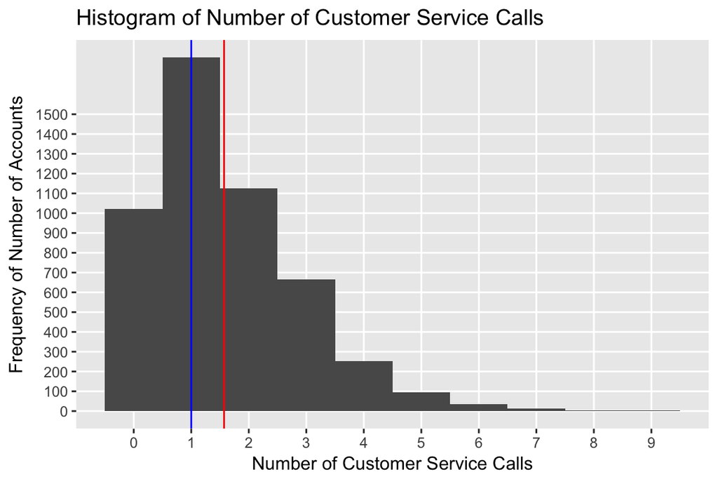

```r
# Histogram of Number of Customer Service Calls
qplot(number.customer.service.calls, data = dt, geom="histogram", binwidth=1) +
  labs(title = "Histogram of Number of Customer Service Calls") +
  labs(x ="Number of Customer Service Calls") +
  labs(y = "Frequency of Number of Accounts") +
  scale_y_continuous(breaks = c(0,100,200,300,400,500,600,700,800,900,1000,1100,1200,1300, 1400, 1500), minor_breaks = NULL) +
  scale_x_continuous(breaks = c(0,1,2,3,4,5,6,7,8,9), minor_breaks = NULL) +
   geom_vline(xintercept = mean(dt$number.customer.service.calls), show.legend=TRUE, color="red", labels("average")) +
  geom_vline(xintercept = median(dt$number.customer.service.calls), show.legend=TRUE, color="blue", labels("Median"))
```

The distribution of the number of customer service calls is far from normally distributed. It’s very right skewed. Most customers only call few times to customer service.

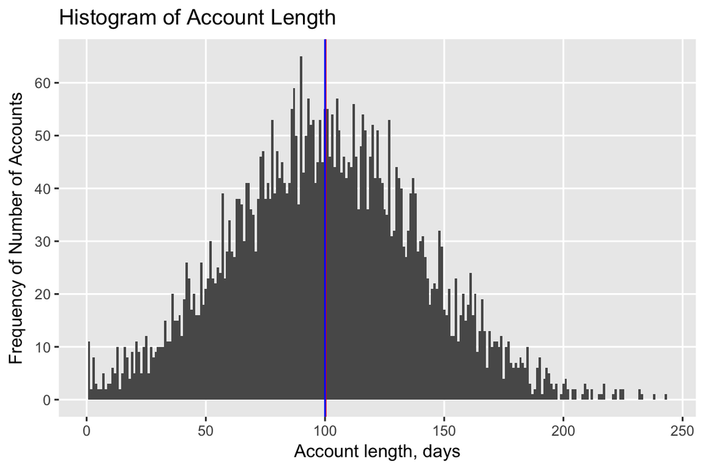

```r
# Histogram of Account Length
qplot(account.length, data = dt, geom="histogram", binwidth=1) +
  labs(title = "Histogram of Account Length") +
  labs(x ="Account length, days") +
  labs(y = "Frequency of Number of Accounts") +
  scale_y_continuous(breaks = c(0,10,20,30,40,50,60,70), minor_breaks = NULL) +
  scale_x_continuous(breaks = c(0,50,100,150,200,250,300), minor_breaks = NULL) +
   geom_vline(xintercept = mean(dt$account.length), show.legend=TRUE, color="red", labels("average")) +
  geom_vline(xintercept = median(dt$account.length), show.legend=TRUE, color="blue", labels("Median"))
```

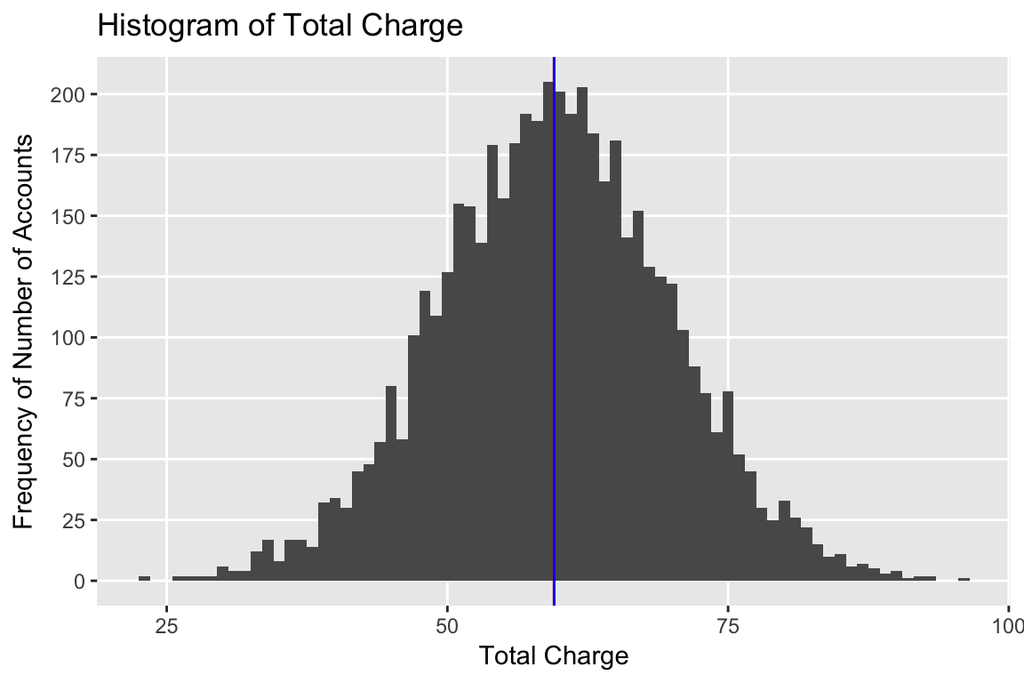

```r
# Histogram of Total Charge
qplot(total.charge, data = dt, geom="histogram", binwidth=1) +
  labs(title = "Histogram of Total Charge") +
  labs(x ="Total Charge") +
  labs(y = "Frequency of Number of Accounts") +
  scale_y_continuous(breaks = c(0,25,50,75,100,125,150,175,200), minor_breaks = NULL) +
  scale_x_continuous(breaks = c(0,25,50,75,100), minor_breaks = NULL) +
   geom_vline(xintercept = mean(dt$total.charge), show.legend=TRUE, color="red", labels("average")) +
  geom_vline(xintercept = median(dt$total.charge), show.legend=TRUE, color="blue", labels("Median"))
```

Account length and total charge are close to normally distributed. Customers seem to vary from very short-term to loyalists and bills vary from very small to substantial.

Next, it’s time to do some logistic regression modeling.

```r
# find the model with glm()
m <- glm(churn ~ number.customer.service.calls + account.length + total.charge, data = dt, family = "binomial")

# print out a summary of the model
summary(m)
```

```
##
## Call:
## glm(formula = churn ~ number.customer.service.calls + account.length +
##     total.charge, family = "binomial", data = dt)
##
## Deviance Residuals:
##     Min       1Q   Median       3Q      Max
## -1.8166  -0.5518  -0.4122  -0.2789   3.1077
##
## Coefficients:
##                                Estimate Std. Error z value Pr(>|z|)
## (Intercept)                   -7.418315   0.328058 -22.613   <2e-16 ***
## number.customer.service.calls  0.451980   0.030470  14.834   <2e-16 ***
## account.length                 0.001582   0.001084   1.459    0.145
## total.charge                   0.074644   0.004520  16.513   <2e-16 ***
## ---
## Signif. codes:  0 '***' 0.001 '**' 0.01 '*' 0.05 '.' 0.1 ' ' 1
##
## (Dispersion parameter for binomial family taken to be 1)
##
##     Null deviance: 4075.0  on 4999  degrees of freedom
## Residual deviance: 3562.6  on 4996  degrees of freedom
## AIC: 3570.6
##
## Number of Fisher Scoring iterations: 5
```

```r
# print out the coefficients of the model
coef(m)
```

```
##                   (Intercept) number.customer.service.calls
##                  -7.418315372                   0.451980350
##                account.length                  total.charge
##                   0.001582076                   0.074643790
```

Seems that number of customer service calls and total charge are statistically significant variables. Account length is not. I’ll drop it from the model.

```r
# find the model with glm()
m <- glm(churn ~ number.customer.service.calls + total.charge, data = dt, family = "binomial")

# print out a summary of the model
summary(m)
```

```
##
## Call:
## glm(formula = churn ~ number.customer.service.calls + total.charge,
##     family = "binomial", data = dt)
##
## Deviance Residuals:
##     Min       1Q   Median       3Q      Max
## -1.8020  -0.5530  -0.4119  -0.2788   3.0806
##
## Coefficients:
##                               Estimate Std. Error z value Pr(>|z|)
## (Intercept)                   -7.25973    0.30852  -23.53   <2e-16 ***
## number.customer.service.calls  0.45207    0.03046   14.84   <2e-16 ***
## total.charge                   0.07466    0.00452   16.52   <2e-16 ***
## ---
## Signif. codes:  0 '***' 0.001 '**' 0.01 '*' 0.05 '.' 0.1 ' ' 1
##
## (Dispersion parameter for binomial family taken to be 1)
##
##     Null deviance: 4075.0  on 4999  degrees of freedom
## Residual deviance: 3564.7  on 4997  degrees of freedom
## AIC: 3570.7
##
## Number of Fisher Scoring iterations: 5
```

```r
# print out the coefficients of the model
coef(m)
```

```
##                   (Intercept) number.customer.service.calls
##                   -7.25972582                    0.45206574
##                  total.charge
##                    0.07465783
```

Explanatory variables have very low p-values. We can be somewhat confident that there is an association between number of customer service calls and total charge with the probability of churn.

Coefficients tell that for one unit increase in customer service calls, the log odds for churn increase 0.452. For one unit increase in total charge, the log odds for churn increase 0.075.

Let’s check the confidence intervals.

```r
confint(m)
```

```
##                                     2.5 %      97.5 %
## (Intercept)                   -7.87242242 -6.66272717
## number.customer.service.calls  0.39261141  0.51205359
## total.charge                   0.06587226  0.08359734
```

As a last thing, I’ll test how well the model predicts.

```r
library(dplyr)
# predict() the probability of churn
probabilities <- predict(m, type = "response")

# add the predicted probabilities to 'dt'
dt <- mutate(dt, probability = probabilities)

# use the probabilities to make a prediction of churn
dt <- mutate(dt, prediction = probability > 0.5)

# tabulate the target variable versus the predictions
table(churn = dt$churn, prediction = dt$prediction)
```

```
##          prediction
## churn     FALSE TRUE
##    False.  4247   46
##    True.    657   50
```

In churn modeling, we are foremost interested about how well the model predicts who’s going to churn. In this case, model predicted churn in 50 cases that did churn. In 657 observations, model suggested not-churn, but the result was churn. This isn’t a good model to predict the churn.

Overall, I wouldn’t use this model to predict churn. Seems that the model is too “cautious” and predicts only small fraction of customers to churn when in reality the churn rate is much higher.